# IODS course project

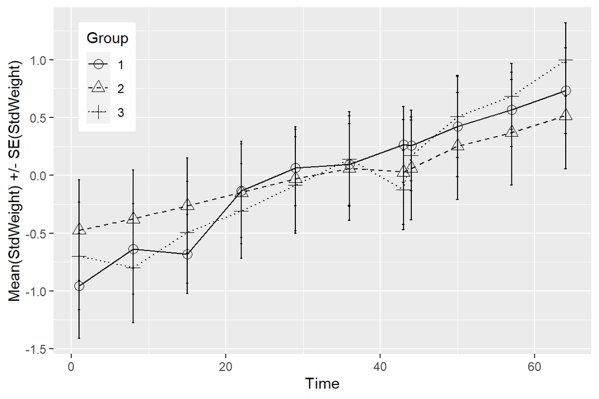

```r
ggplot(RATSS, aes(x = Time, y = mean, linetype = Group, shape = Group)) +
  geom_line() +
  scale_linetype_manual(values = c(1,2,3)) +
  geom_point(size=3) +
  scale_shape_manual(values = c(1,2,3)) +
  geom_errorbar(aes(ymin = mean - se, ymax = mean + se, linetype="1"), width=0.3) +
  theme(legend.position = c(0.1,0.8)) +
  scale_y_continuous(name = "Mean(StdWeight) +/- SE(StdWeight)")
```

Mean response profiles for the three treatment groups reveal no difference in weight gain across diets.

```r
RATSL8S <- RATSL %>%
  group_by(Group, ID) %>%
  summarise( mean=mean(stdweight) ) %>%
  ungroup()
glimpse(RATSL8S)
```

```
## Rows: 16
## Columns: 3
## $ Group <fct> 1, 1, 1, 1, 1, 1, 1, 1, 2, 2, 2, 2, 3, 3, 3, 3
## $ ID    <fct> 1, 2, 3, 4, 5, 6, 7, 8, 9, 10, 11, 12, 13, 14, 15, 16
## $ mean  <dbl> -0.1917770, -1.9053168, -0.2581933, 0.2067206, 0.4192527, 0.8044~
```

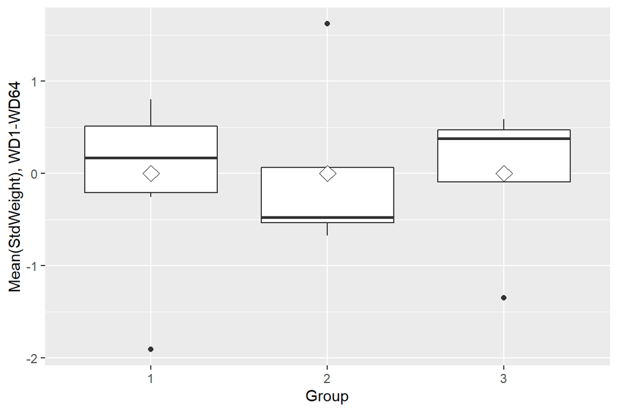

```r
ggplot(RATSL8S, aes(x = Group, y = mean)) +
  geom_boxplot() +
  stat_summary(fun = "mean", geom = "point", shape=23, size=4, fill = "white") +
  scale_y_continuous(name = "Mean(StdWeight), WD1-WD64")
```

Box plots of standardized mean summary weights by the three treatment groups suggest one outlier per Group.

```r
RATSL8S1 <- RATSL8S %>%
  filter(between(mean, -1, 1))
glimpse(RATSL8S1)
```

```
## Rows: 13
## Columns: 3
## $ Group <fct> 1, 1, 1, 1, 1, 1, 1, 2, 2, 2, 3, 3, 3
## $ ID    <fct> 1, 3, 4, 5, 6, 7, 8, 9, 10, 11, 14, 15, 16
## $ mean  <dbl> -0.1917770, -0.2581933, 0.2067206, 0.4192527, 0.8044671, 0.79782~
```

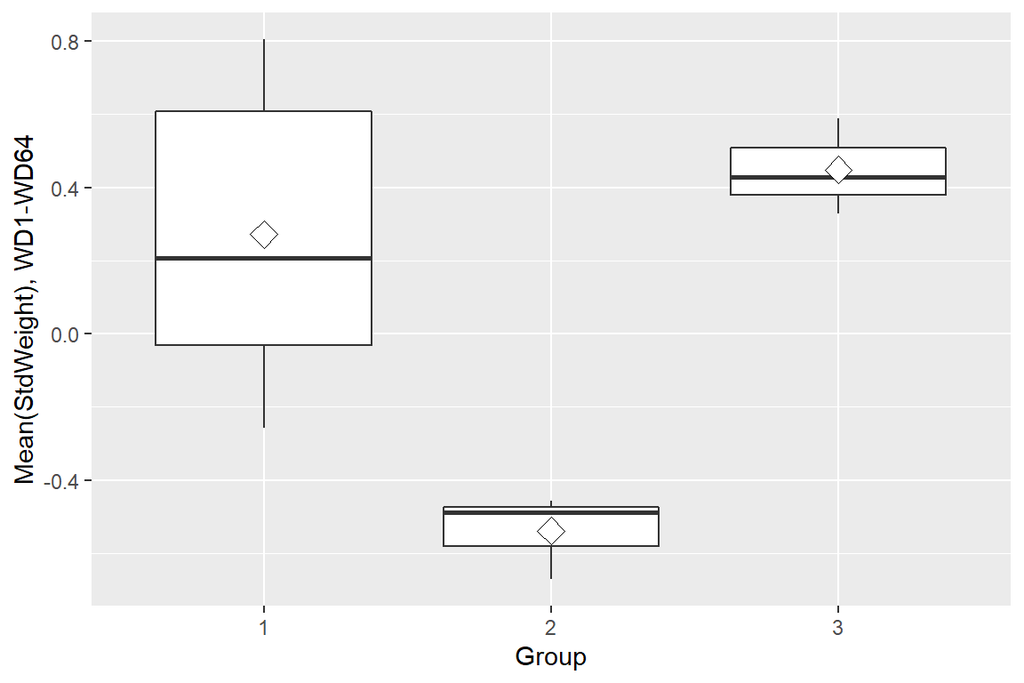

```r
ggplot(RATSL8S1, aes(x = Group, y = mean)) +
  geom_boxplot() +
  stat_summary(fun = "mean", geom = "point", shape=23, size=4, fill = "white") +
  scale_y_continuous(name = "Mean(StdWeight), WD1-WD64")
```

After removing the outliers, the box plots indicate difference in weight gain across diets. Group 2 has gained less weight.

```r
summary(aov(mean ~ Group, data = RATSL8S1, var.equal = TRUE))
```

```
##             Df Sum Sq Mean Sq F value  Pr(>F)
## Group        2  1.790  0.8949   7.686 0.00951 **
## Residuals   10  1.164  0.1164
## ---
## Signif. codes:  0 '***' 0.001 '**' 0.01 '*' 0.05 '.' 0.1 ' ' 1
```

One-Way ANOVA verifies the box plot; there is a statistically significant difference in weight gain across diets after removing three outliers. The test P-value for Group is ~0.010.

```r
RATS <- read_csv("RATS.csv")
```

```
## * `` -> ...1
```

```r
RATSL8S2 <- RATSL8S %>%
  mutate(baseline = RATS$WD1)
fit <- lm(mean ~ baseline + Group, data = RATSL8S2)
anova(fit)
```

```
## Analysis of Variance Table
##
## Response: mean
##           Df Sum Sq Mean Sq F value   Pr(>F)
## baseline   1 0.5888  0.5888  1.9158 0.191524
## Group      2 6.9420  3.4710 11.2928 0.001745 **
## Residuals 12 3.6884  0.3074
## ---
## Signif. codes:  0 '***' 0.001 '**' 0.01 '*' 0.05 '.' 0.1 ' ' 1
```

Using the first weight values (WD1) as covariates in the ANOVA does not change the interpretation. There still is a statistically significant difference in weight gain across diets. The test P-value for Group is ~0.002.

**SECOND, I implemented the analyses of Chapter 9 of MABS using the BPRS data.**

Before plotting the data and running the analyses, I added unique IDs for the subjects. In the original data, the **subject** variable does not distinguish the subjects by the treatment, only within the treatments.

```r
library(readr)
BPRSL <- read_csv("data/BPRSL.csv", col_types = cols(treatment = col_factor(levels = c("1",
    "2")), subject = col_factor(levels = c("1",
    "2", "3", "4", "5", "6", "7", "8", "9",
    "10", "11", "12", "13", "14", "15", "16",
    "17", "18", "19", "20"))))
```

```
## * `` -> ...1
```

```r
ID2 <- c(21,22,23,24,25,26,27,28,29,30,31,32,33,34,35,36,37,38,39,40)
BPRSL <- mutate(BPRSL, ID = ifelse(treatment==1, subject,ID2))
BPRSL$ID <- factor(BPRSL$ID)
names(BPRSL)
```

```
## [1] "...1"      "treatment" "subject"   "weeks"     "bprs"      "week"
## [7] "ID"
```

```r
summary(BPRSL)
```

```
##       ...1        treatment    subject       weeks                bprs
##  Min.   :  1.00   1:180     1      : 18   Length:360         Min.   :18.00
##  1st Qu.: 90.75   2:180     2      : 18   Class :character   1st Qu.:27.00
##  Median :180.50             3      : 18   Mode  :character   Median :35.00
##  Mean   :180.50             4      : 18                      Mean   :37.66
##  3rd Qu.:270.25             5      : 18                      3rd Qu.:43.00
##  Max.   :360.00             6      : 18                      Max.   :95.00
##                             (Other):252
##       week         ID
##  Min.   :0   1      :  9
##  1st Qu.:2   2      :  9
##  Median :4   3      :  9
##  Mean   :4   4      :  9
##  3rd Qu.:6   5      :  9
##  Max.   :8   6      :  9
##              (Other):306
```

```r
glimpse(BPRSL)
```

```
## Rows: 360
## Columns: 7
## $ ...1      <dbl> 1, 2, 3, 4, 5, 6, 7, 8, 9, 10, 11, 12, 13, 14, 15, 16, 17, 1~
## $ treatment <fct> 1, 1, 1, 1, 1, 1, 1, 1, 1, 1, 1, 1, 1, 1, 1, 1, 1, 1, 1, 1, ~
## $ subject   <fct> 1, 2, 3, 4, 5, 6, 7, 8, 9, 10, 11, 12, 13, 14, 15, 16, 17, 1~
## $ weeks     <chr> "week0", "week0", "week0", "week0", "week0", "week0", "week0~
## $ bprs      <dbl> 42, 58, 54, 55, 72, 48, 71, 30, 41, 57, 30, 55, 36, 38, 66, ~
## $ week      <dbl> 0, 0, 0, 0, 0, 0, 0, 0, 0, 0, 0, 0, 0, 0, 0, 0, 0, 0, 0, 0, ~
## $ ID        <fct> 1, 2, 3, 4, 5, 6, 7, 8, 9, 10, 11, 12, 13, 14, 15, 16, 17, 1~
```

```r
library(dplyr)
library(tidyr)
library(ggplot2)
dim(BPRSL)
```

```
## [1] 360   7
```

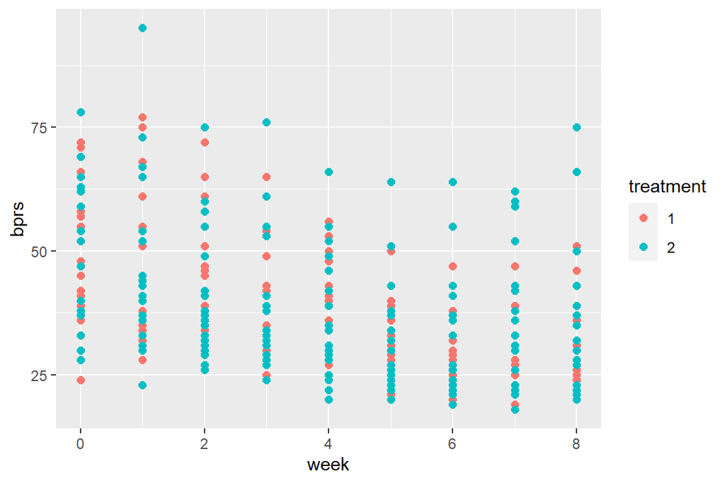

```r
ggplot(BPRSL, aes(x = week, y = bprs, group = treatment)) + geom_point(aes(colour = treatment), size = 2)
```

```r
BPRSS <- BPRSL %>%
  group_by(treatment, week) %>%
  summarise( mean = mean(bprs) ) %>%
  ungroup()
```

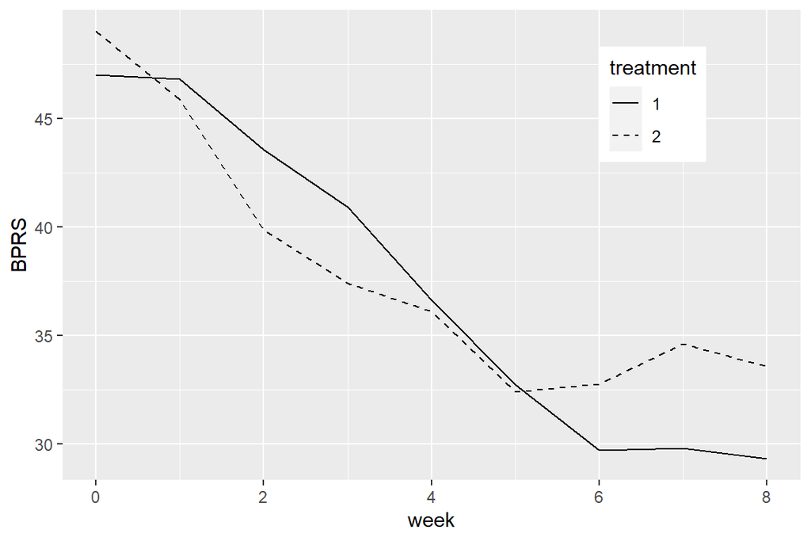

```r
ggplot(BPRSS, aes(x = week, y = mean, linetype = treatment, shape = treatment)) +
  geom_line() +
  scale_linetype_manual(values = c(1,2)) +
  theme(legend.position = c(0.8,0.8)) +
  scale_y_continuous(name = "BPRS")
```